# OSM data acquisition notebook

**Description**

This notebook downloads OpenStreetMap(OSM) data via osmnx library. These data are used for creating public urban green spaces (PUGS) mask to feed as an input to deep learning model in later step.

The data within the specific bounding box are downloaded from the below tag lists:

[output not shown]

For **footpath network**, it is downloaded from osmnx by using `graph_from_bbox` function (network_type='walk')

```
footpath_network = ox.graph_from_bbox(city_bbox, network_type='walk')
```

**Input file(s)**

There is no required input files.

**Output file(s)**

- LULC related to green spaces from landuse tag (`green_landuse_area_dresden.geojson`)
- LULC related to green spaces from leisure tag (`green_leisure_area_dresden.geojson`)
- LULC related to green spaces from natural tag (`green_natural_area_dresden.geojson`)
- LULC related to green spaces from campsite tag (`green_campsite_area_dresden.geojson`)
- Location of POI from amenity tag (`poi_amenity_dresden.geojson`)
- Location of POI from leisure tag (`poi_leisure_dresden.geojson`)
- Location of POI from viewpoint tag (`poi_viewpoint_dresden.geojson`)
- Footpath network (`footpath_network_edges.geojson`)

*LULC = Land use/Land cover*

**Requirements/Dependencies**

This notebook doesn't have dependency with other notebooks.

# 1. Import libraries and load config

```python
import osmnx as ox
import os
import yaml
```

```python
# Load config
with open("../config.yaml", "r") as f:
    config = yaml.safe_load(f)
```

```python
# set crs
crs = config["data"]["crs"]
```

# 2. Get Dresden boundary and bounding box from OSM

```python
# place_name = "Altstadt, Dresden, Germany"
place_name = config["general"]["place_name"]
```

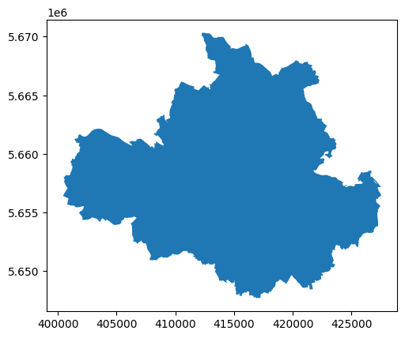

```python
city = ox.geocode_to_gdf(place_name)
ax = ox.projection.project_gdf(city).plot()
```

```python
# city_bbox = [13.6864402, 51.0280799, 13.7872926, 51.0766681] # Altstadt, Dresden

# minx, miny, maxx, maxy (left, bottom, right, top)
city_bbox = list(city.total_bounds)  # Dresden
```

```python
city = city.to_crs(epsg=crs)
```

```python
geojson_output_path = config["paths"]["dresden_boundary_path"]

if not os.path.exists(os.path.dirname(geojson_output_path)):
    os.makedirs(os.path.dirname(geojson_output_path))

city.to_file(geojson_output_path, driver="GeoJSON")
```

# 3. Get green space related area from OSM

## 3.1. Use landuse key

```python
green_landuse_area = ox.features_from_bbox(
    city_bbox,
    tags={
        "landuse": [
            "allotments",
            "forest",
            "grass",
            "greenfield",
            "meadow",
            "orchard",
            "recreation_ground",
            "village_green",
            "vineyard",
            "cemetery",
        ]
    },
)
```

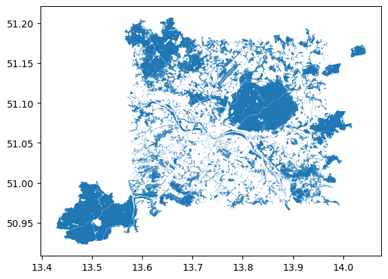

```python
green_landuse_area.plot()
```

```python
green_landuse_area = green_landuse_area.reset_index()
```

```python
green_landuse_area.head(3)
```

|  | element | id | geometry | landuse | name | denomination | religion | wikidata | check_date:opening_hours | opening_hours | ... | bridge | substance | utility | was:man_made | name:en | level | material | type | name:hsb | source:outline |
| --- | --- | --- | --- | --- | --- | --- | --- | --- | --- | --- | --- | --- | --- | --- | --- | --- | --- | --- | --- | --- | --- |
| 0 | node | 593500300 | POINT (13.70638 51.15663) | meadow | Fasanenwiese | NaN | NaN | NaN | NaN | NaN | ... | NaN | NaN | NaN | NaN | NaN | NaN | NaN | NaN | NaN | NaN |
| 1 | node | 593504848 | POINT (13.70344 51.15098) | forest | Fuchsbruch | NaN | NaN | NaN | NaN | NaN | ... | NaN | NaN | NaN | NaN | NaN | NaN | NaN | NaN | NaN | NaN |
| 2 | relation | 6128 | MULTIPOLYGON (((13.89557 51.10721, 13.89696 51... | forest | Dresdner Heide | NaN | NaN | Q8905 | NaN | NaN | ... | NaN | NaN | NaN | NaN | NaN | NaN | NaN | multipolygon | Drježdźanska hola | NaN |

3 rows × 126 columns

```python
geojson_output_path = config["paths"]["green_landuse_path"]

if not os.path.exists(os.path.dirname(geojson_output_path)):
    os.makedirs(os.path.dirname(geojson_output_path))

green_landuse_area.to_file(geojson_output_path, driver="GeoJSON")
```

## 3.2. Use leisure key

```python
green_leisure_area = ox.features_from_bbox(
    city_bbox,
    tags={
        "leisure": [
            "garden",
            "golf_course",
            "nature_reserve",
            "park",
            "pitch",
            "playground",
            "dog_park",
        ]
    },
)
```

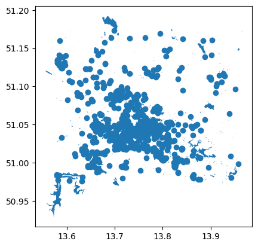

```python
green_leisure_area.plot()
```

```python
green_leisure_area = green_leisure_area.reset_index()
```

```python
green_leisure_area.head(3)
```

|  | element | id | geometry | created_by | leisure | wheelchair | access | name | opening_hours | operator | ... | noname | name:de | pitch:net | pitch:net:material | pitch:net:overhang | construction | operator:short | animal_training | type | name:fr |
| --- | --- | --- | --- | --- | --- | --- | --- | --- | --- | --- | --- | --- | --- | --- | --- | --- | --- | --- | --- | --- | --- |
| 0 | node | 255545201 | POINT (13.71593 51.02135) | Potlatch 0.8a | playground | no | NaN | NaN | NaN | NaN | ... | NaN | NaN | NaN | NaN | NaN | NaN | NaN | NaN | NaN | NaN |
| 1 | node | 262693384 | POINT (13.77654 51.1137) | JOSM | playground | limited | NaN | NaN | NaN | NaN | ... | NaN | NaN | NaN | NaN | NaN | NaN | NaN | NaN | NaN | NaN |
| 2 | node | 266593887 | POINT (13.71519 51.0301) | NaN | playground | NaN | yes | Würzburger Straße - Park | Mo-Su 08:00-22:00 | Landeshauptstadt Dresden | ... | NaN | NaN | NaN | NaN | NaN | NaN | NaN | NaN | NaN | NaN |

3 rows × 149 columns

```python
geojson_output_path = config["paths"]["green_leisure_path"]

if not os.path.exists(os.path.dirname(geojson_output_path)):
    os.makedirs(os.path.dirname(geojson_output_path))

green_leisure_area.to_file(geojson_output_path, driver="GeoJSON")
```

## 3.3. Use natural key

```python
green_natural_area = ox.features_from_bbox(
    city_bbox, tags={"natural": ["wood", "scrub", "heath", "grassland", "wetland"]}
)
```

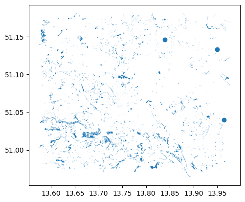

```python
green_natural_area.plot()
```

```python
green_natural_area = green_natural_area.reset_index()
```

```python
green_natural_area.head(3)
```

|  | element | id | geometry | natural | wetland | name | source:name | old_name | source | boundary | ... | access | comment | area | check_date | area:highway | fee | species:wikipedia | type | nature | protected_area |
| --- | --- | --- | --- | --- | --- | --- | --- | --- | --- | --- | --- | --- | --- | --- | --- | --- | --- | --- | --- | --- | --- |
| 0 | node | 2583496631 | POINT (13.83905 51.14606) | wetland | swamp | NaN | NaN | NaN | NaN | NaN | ... | NaN | NaN | NaN | NaN | NaN | NaN | NaN | NaN | NaN | NaN |
| 1 | node | 9042465204 | POINT (13.96352 51.03965) | wood | NaN | Kirsten Buschgen | Meilenblatt Sachsen 1783 | NaN | NaN | NaN | ... | NaN | NaN | NaN | NaN | NaN | NaN | NaN | NaN | NaN | NaN |
| 2 | node | 9124027180 | POINT (13.94931 51.13272) | wood | NaN | Der Strang | NaN | Strange Holtz | Meilenblätter Sachsen 1783 Blatt 264 | NaN | ... | NaN | NaN | NaN | NaN | NaN | NaN | NaN | NaN | NaN | NaN |

3 rows × 80 columns

```python
geojson_output_path = config["paths"]["green_natural_path"]

if not os.path.exists(os.path.dirname(geojson_output_path)):
    os.makedirs(os.path.dirname(geojson_output_path))

green_natural_area.to_file(geojson_output_path, driver="GeoJSON")
```

## 3.4. Use tourism key

```python
green_campsite_area = ox.features_from_bbox(
    city_bbox, tags={"tourism": ["camp_site", "picnic_site", "caravan_site", "zoo"]}
)
```

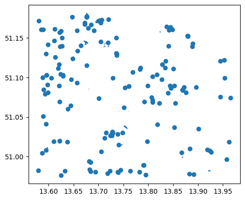

```python
green_campsite_area.plot()
```

```python
green_campsite_area = green_campsite_area.reset_index()
```

```python
green_campsite_area.head(3)
```

|  | element | id | geometry | created_by | tourism | access | addr:city | addr:country | addr:housenumber | addr:postcode | ... | mobile | motor_vehicle | beds | group_only | guest_house | rooms | attraction | capacity:disabled | seasonal | socket:cee_blue |
| --- | --- | --- | --- | --- | --- | --- | --- | --- | --- | --- | --- | --- | --- | --- | --- | --- | --- | --- | --- | --- | --- |
| 0 | node | 257564076 | POINT (13.73661 51.12991) | JOSM | picnic_site | NaN | NaN | NaN | NaN | NaN | ... | NaN | NaN | NaN | NaN | NaN | NaN | NaN | NaN | NaN | NaN |
| 1 | node | 257564078 | POINT (13.73708 51.12782) | JOSM | picnic_site | NaN | NaN | NaN | NaN | NaN | ... | NaN | NaN | NaN | NaN | NaN | NaN | NaN | NaN | NaN | NaN |
| 2 | node | 257922815 | POINT (13.73613 51.13039) | JOSM | picnic_site | NaN | NaN | NaN | NaN | NaN | ... | NaN | NaN | NaN | NaN | NaN | NaN | NaN | NaN | NaN | NaN |

3 rows × 115 columns

```python
geojson_output_path = config["paths"]["green_campsite_path"]

if not os.path.exists(os.path.dirname(geojson_output_path)):
    os.makedirs(os.path.dirname(geojson_output_path))

green_campsite_area.to_file(geojson_output_path, driver="GeoJSON")
```

# 4. Get POI from OSM

## 4.1. Use amenity key

```python
poi_amenity_gdf = ox.features_from_bbox(
    city_bbox, tags={"amenity": ["bench", "waste_basket"]}
)
```

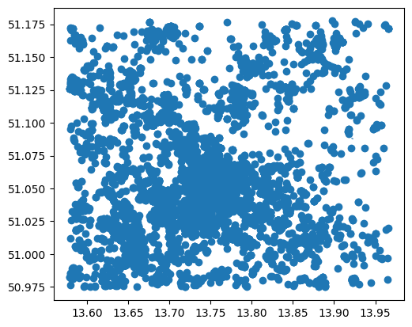

```python
poi_amenity_gdf.plot()
```

```python
poi_amenity_gdf = poi_amenity_gdf.reset_index()
```

```python
poi_amenity_gdf.head(3)
```

|  | element | id | geometry | amenity | backrest | description | direction | material | seats | wikimedia_commons | ... | not:vending | deposit_ring | support | seats:separated | outdoor_seating | leisure | barrier | height | area | man_made |
| --- | --- | --- | --- | --- | --- | --- | --- | --- | --- | --- | --- | --- | --- | --- | --- | --- | --- | --- | --- | --- | --- |
| 0 | node | 251567329 | POINT (13.62835 50.98787) | bench | yes | Bank am Zickzack-Weg | 100 | wood | 3 | File:Bank am Zickzackweg.jpg | ... | NaN | NaN | NaN | NaN | NaN | NaN | NaN | NaN | NaN | NaN |
| 1 | node | 255298026 | POINT (13.79864 51.0468) | bench | yes | NaN | NaN | NaN | NaN | NaN | ... | NaN | NaN | NaN | NaN | NaN | NaN | NaN | NaN | NaN | NaN |
| 2 | node | 255925960 | POINT (13.70218 51.03911) | waste_basket | NaN | NaN | NaN | NaN | NaN | NaN | ... | NaN | NaN | NaN | NaN | NaN | NaN | NaN | NaN | NaN | NaN |

3 rows × 83 columns

```python
geojson_output_path = config["paths"]["poi_amenity_path"]

if not os.path.exists(os.path.dirname(geojson_output_path)):
    os.makedirs(os.path.dirname(geojson_output_path))

poi_amenity_gdf.to_file(geojson_output_path, driver="GeoJSON")
```

## 4.2. Use leisure key

```python
poi_leisure_gdf = ox.features_from_bbox(
    city_bbox, tags={"leisure": ["picnic_table", "playground"]}
)
```

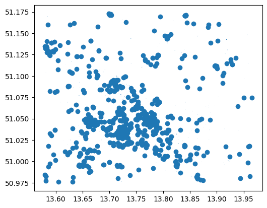

```python
poi_leisure_gdf.plot()
```

```python
poi_leisure_gdf = poi_leisure_gdf.reset_index()
```

```python
poi_leisure_gdf.head(3)
```

|  | element | id | geometry | created_by | leisure | wheelchair | access | name | opening_hours | operator | ... | pets | playground:springy | fixme | start_date | contact:email | contact:mobile | contact:website | addr:suburb | construction | type |
| --- | --- | --- | --- | --- | --- | --- | --- | --- | --- | --- | --- | --- | --- | --- | --- | --- | --- | --- | --- | --- | --- |
| 0 | node | 255545201 | POINT (13.71593 51.02135) | Potlatch 0.8a | playground | no | NaN | NaN | NaN | NaN | ... | NaN | NaN | NaN | NaN | NaN | NaN | NaN | NaN | NaN | NaN |
| 1 | node | 262693384 | POINT (13.77654 51.1137) | JOSM | playground | limited | NaN | NaN | NaN | NaN | ... | NaN | NaN | NaN | NaN | NaN | NaN | NaN | NaN | NaN | NaN |
| 2 | node | 266593887 | POINT (13.71519 51.0301) | NaN | playground | NaN | yes | Würzburger Straße - Park | Mo-Su 08:00-22:00 | Landeshauptstadt Dresden | ... | NaN | NaN | NaN | NaN | NaN | NaN | NaN | NaN | NaN | NaN |

3 rows × 84 columns

```python
geojson_output_path = config["paths"]["poi_leisure_path"]

if not os.path.exists(os.path.dirname(geojson_output_path)):
    os.makedirs(os.path.dirname(geojson_output_path))

poi_leisure_gdf.to_file(geojson_output_path, driver="GeoJSON")
```

## 4.3. Use tourism key

```python
poi_viewpoint_gdf = ox.features_from_bbox(city_bbox, tags={"tourism": ["viewpoint"]})
```

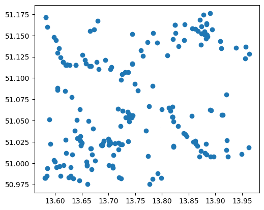

```python
poi_viewpoint_gdf.plot()
```

```python
poi_viewpoint_gdf = poi_viewpoint_gdf.reset_index()
```

```python
poi_viewpoint_gdf.head(3)
```

|  | element | id | geometry | highway | toilets:wheelchair | tourism | wheelchair | name | name:de | noexit | ... | monument:genesis | source | tower:construction | charge | comment | old_name | loc_name | subject:wikipedia | building:levels | name:en |
| --- | --- | --- | --- | --- | --- | --- | --- | --- | --- | --- | --- | --- | --- | --- | --- | --- | --- | --- | --- | --- | --- |
| 0 | node | 67366424 | POINT (13.6271 51.11517) | turning_circle | yes | viewpoint | yes | NaN | NaN | NaN | ... | NaN | NaN | NaN | NaN | NaN | NaN | NaN | NaN | NaN | NaN |
| 1 | node | 71744963 | POINT (13.6653 51.15523) | NaN | NaN | viewpoint | NaN | NaN | NaN | NaN | ... | NaN | NaN | NaN | NaN | NaN | NaN | NaN | NaN | NaN | NaN |
| 2 | node | 248567811 | POINT (13.73201 51.05379) | NaN | NaN | viewpoint | no | Am Zwingergraben | Am Zwingergraben | yes | ... | NaN | NaN | NaN | NaN | NaN | NaN | NaN | NaN | NaN | NaN |

3 rows × 75 columns

```python
geojson_output_path = config["paths"]["poi_viewpoint_path"]

if not os.path.exists(os.path.dirname(geojson_output_path)):
    os.makedirs(os.path.dirname(geojson_output_path))

poi_viewpoint_gdf.to_file(geojson_output_path, driver="GeoJSON")
```

# 5. Get walking path (footpath)

```python
footpath_network = ox.graph_from_bbox(city_bbox, network_type="walk")
```

```python
footpath_nodes, footpath_edges = ox.graph_to_gdfs(footpath_network)
```

```python
footpath_nodes = footpath_nodes.reset_index()
footpath_edges = footpath_edges.reset_index()
```

```python
footpath_nodes.head(3)
```

|  | osmid | y | x | street_count | highway | junction | railway | ref | geometry |
| --- | --- | --- | --- | --- | --- | --- | --- | --- | --- |
| 0 | 442734 | 51.016632 | 13.736979 | 3 | NaN | NaN | NaN | NaN | POINT (13.73698 51.01663) |
| 1 | 442736 | 51.016695 | 13.739391 | 3 | NaN | NaN | NaN | NaN | POINT (13.73939 51.01669) |
| 2 | 442738 | 51.017268 | 13.740166 | 3 | NaN | NaN | NaN | NaN | POINT (13.74017 51.01727) |

```python
footpath_edges.head(3)
```

|  | u | v | key | osmid | highway | maxspeed | name | oneway | reversed | length | ... | service | lanes | bridge | access | width | ref | junction | est_width | tunnel | area |
| --- | --- | --- | --- | --- | --- | --- | --- | --- | --- | --- | --- | --- | --- | --- | --- | --- | --- | --- | --- | --- | --- |
| 0 | 442734 | 1839778041 | 0 | 1338016415 | residential | 30 | Altpestitz | False | True | 72.940783 | ... | NaN | NaN | NaN | NaN | NaN | NaN | NaN | NaN | NaN | NaN |
| 1 | 442734 | 442736 | 0 | 92 | residential | 30 | Eigenheimstraße | False | False | 169.821618 | ... | NaN | NaN | NaN | NaN | NaN | NaN | NaN | NaN | NaN | NaN |
| 2 | 442734 | 9907191675 | 0 | 105 | residential | 30 | Altpestitz | False | False | 55.779311 | ... | NaN | NaN | NaN | NaN | NaN | NaN | NaN | NaN | NaN | NaN |

3 rows × 21 columns

## Reassign one single access value (public/private) to the footpath edge

```python
# Check if 'access' column contains lists
is_list = footpath_edges["access"].apply(lambda x: isinstance(x, list))

# Count how many values in 'access' column are lists
list_count = is_list.sum()
total_count = len(footpath_edges)

print(f"{list_count} out of {total_count} values are lists")
```

```
36 out of 313296 values are lists
```

```python
# If it contains non-public access, we will assign non-public value
for row in footpath_edges.itertuples():
    if isinstance(row.access, list):
        if (
            ("yes" not in row.access)
            | ("permissive" not in row.access)
            | ("public" in row.access)
        ):
            footpath_edges.at[row.Index, "access"] = "private"
        else:
            footpath_edges.at[row.Index, "access"] = "public"
```

```python
# Check if 'access' column contains lists
is_list = footpath_edges["access"].apply(lambda x: isinstance(x, list))

# Count how many values in 'access' column are lists
list_count = is_list.sum()
total_count = len(footpath_edges)

print(f"{list_count} out of {total_count} values are lists")
```

```
0 out of 313296 values are lists
```

```python
geojson_output_path = config["paths"]["footpath_network_path"]

if not os.path.exists(os.path.dirname(geojson_output_path)):
    os.makedirs(os.path.dirname(geojson_output_path))

footpath_edges.to_file(geojson_output_path, driver="GeoJSON")
```